# AIforesee_KadekYukiAndika

```python
import numpy as np
import pandas as pd
import matplotlib.pyplot as plt
import seaborn as sns
import scipy.stats as stats
from sklearn.model_selection import train_test_split
from sklearn.preprocessing import StandardScaler
from sklearn.model_selection import GridSearchCV
from sklearn.linear_model import LogisticRegression
from sklearn.tree import DecisionTreeClassifier
from xgboost import XGBClassifier
from sklearn.metrics import classification_report,r2_score, mean_squared_error, mean_absolute_error
from sklearn.preprocessing import PolynomialFeatures
from xgboost import XGBRegressor
from sklearn.pipeline import Pipeline
from sklearn.linear_model import LinearRegression
from tensorflow import keras
from sklearn.model_selection import GridSearchCV
from keras.wrappers.scikit_learn import KerasClassifier
from sklearn.model_selection import StratifiedKFold
from sklearn.utils.class_weight import compute_class_weight
```

```python
df = pd.read_csv('loan_final313.csv')
df.head()
```

|  | id | year | issue_d | final_d | emp_length_int | home_ownership | home_ownership_cat | income_category | annual_inc | income_cat | ... | loan_condition_cat | interest_rate | grade | grade_cat | dti | total_pymnt | total_rec_prncp | recoveries | installment | region |
| --- | --- | --- | --- | --- | --- | --- | --- | --- | --- | --- | --- | --- | --- | --- | --- | --- | --- | --- | --- | --- | --- |
| 0 | 1077501 | 2011 | 01/12/2011 | 1012015 | 10.0 | RENT | 1 | Low | 24000 | 1 | ... | 0 | 10.65 | B | 2 | 27.65 | 5861.071414 | 5000.00 | 0.00 | 162.87 | munster |
| 1 | 1077430 | 2011 | 01/12/2011 | 1042013 | 0.5 | RENT | 1 | Low | 30000 | 1 | ... | 1 | 15.27 | C | 3 | 1.00 | 1008.710000 | 456.46 | 117.08 | 59.83 | leinster |
| 2 | 1077175 | 2011 | 01/12/2011 | 1062014 | 10.0 | RENT | 1 | Low | 12252 | 1 | ... | 0 | 15.96 | C | 3 | 8.72 | 3003.653644 | 2400.00 | 0.00 | 84.33 | cannught |
| 3 | 1076863 | 2011 | 01/12/2011 | 1012015 | 10.0 | RENT | 1 | Low | 49200 | 1 | ... | 0 | 13.49 | C | 3 | 20.00 | 12226.302210 | 10000.00 | 0.00 | 339.31 | ulster |
| 4 | 1075358 | 2011 | 01/12/2011 | 1012016 | 1.0 | RENT | 1 | Low | 80000 | 1 | ... | 0 | 12.69 | B | 2 | 17.94 | 3242.170000 | 2233.10 | 0.00 | 67.79 | ulster |

5 rows × 30 columns

```python
df.info()
```

```
<class 'pandas.core.frame.DataFrame'>
RangeIndex: 887379 entries, 0 to 887378
Data columns (total 30 columns):
 #   Column                Non-Null Count   Dtype
---  ------                --------------   -----
 0   id                    887379 non-null  int64
 1   year                  887379 non-null  int64
 2   issue_d               887379 non-null  object
 3   final_d               887379 non-null  int64
 4   emp_length_int        887379 non-null  float64
 5   home_ownership        887379 non-null  object
 6   home_ownership_cat    887379 non-null  int64
 7   income_category       887379 non-null  object
 8   annual_inc            887379 non-null  int64
 9   income_cat            887379 non-null  int64
```

[output cut: 22 more lines]

- There are 887379 rows and 30 columns. Each columns has 887379 non-null values. It means there are no missing value in this data.
- issue_d and final_d columns data form need to be adjusted.

```python
#Change data type issue_d and final_d column
df['issue_d'] = pd.to_datetime(df['issue_d'], format='%d/%m/%Y')
df['final_d'] = pd.to_datetime(df['final_d'], format='%d%m%Y')
```

```python
#check number of unique data
df.nunique()
```

```
id                      887379
year                         9
issue_d                    103
final_d                     98
emp_length_int              12
home_ownership               6
home_ownership_cat           6
income_category              3
annual_inc               45784
income_cat                   3
loan_amount               1372
term                         2
term_cat                     2
application_type             2
application_type_cat         2
purpose                     14
purpose_cat                 14
interest_payments            2
interest_payment_cat         2
loan_condition               2
loan_condition_cat           2
interest_rate              542
grade                        7
grade_cat                    7
dti                       4086
total_pymnt             505628
total_rec_prncp         260227
recoveries               23055
installment              68711
region                       5
dtype: int64
```

```python
df[df['year']!=df['issue_d'].dt.year]
```

|  | id | year | issue_d | final_d | emp_length_int | home_ownership | home_ownership_cat | income_category | annual_inc | income_cat | ... | loan_condition_cat | interest_rate | grade | grade_cat | dti | total_pymnt | total_rec_prncp | recoveries | installment | region |
| --- | --- | --- | --- | --- | --- | --- | --- | --- | --- | --- | --- | --- | --- | --- | --- | --- | --- | --- | --- | --- | --- |

0 rows × 30 columns

- id column doesn't help to analyze so I will drop the column
- year columns is not useful since the values has been contains at issue_d column, so I will drop the columns as well
- issue_d and final_d columns don't give a information, I will use the difference of the both columns (in month) and look up wheter there are correlation with label (desired output)

```python
#drop useless columns
df.drop(['id','year'],inplace=True,axis=1)
```

```python
# Change the 'issue_d' and 'final_d' to month period
issue_d_monthly = df['issue_d'].dt.to_period('M').astype(int)
final_d_monthly = df['final_d'].dt.to_period('M').astype(int)

# Deterimine the month difference
df['month_diff'] = (final_d_monthly - issue_d_monthly)

#drop issue_d and final_d columns
df.drop(['issue_d','final_d'],inplace=True,axis=1)
```

[output not shown]

```python
df.columns
```

```
Index(['emp_length_int', 'home_ownership', 'home_ownership_cat',
       'income_category', 'annual_inc', 'income_cat', 'loan_amount', 'term',
       'term_cat', 'application_type', 'application_type_cat', 'purpose',
       'purpose_cat', 'interest_payments', 'interest_payment_cat',
       'loan_condition', 'loan_condition_cat', 'interest_rate', 'grade',
       'grade_cat', 'dti', 'total_pymnt', 'total_rec_prncp', 'recoveries',
       'installment', 'region', 'month_diff'],
      dtype='object')
```

There are categorical columns that have been converted to numerical columns. I will not drop the columns right know because I will make the categorical label to plot bar chart. Now, I will separate between categorical and numerical columns.

```python
#Categorical columns
cat_cols= ['home_ownership','income_category','term','application_type','purpose','interest_payments','loan_condition','grade','region']

#encoding categorical columns
cat_cols_new=['home_ownership_cat','income_cat','term_cat','application_type_cat','purpose_cat','interest_payment_cat','loan_condition_cat','grade_cat']

#Numereical columns
num_cols=['emp_length_int','annual_inc','loan_amount','interest_rate','dti','total_pymnt','total_rec_prncp','recoveries','installment','month_diff']
```

## EDA Univariate

Histogram with distribution curve and a boxplot for each numerical columns

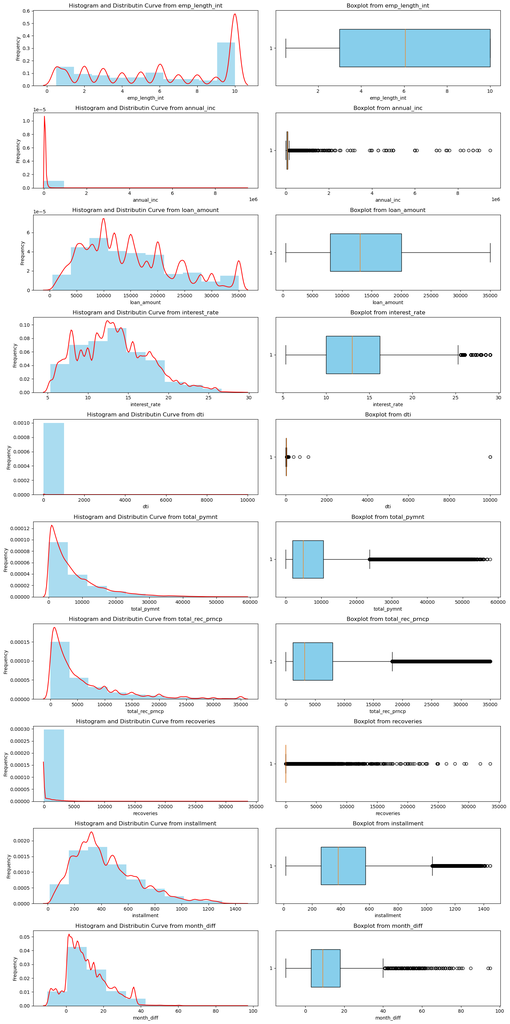

```python
fig, axs = plt.subplots(nrows=len(num_cols), ncols=2, figsize=(15, len(num_cols)*3))
for i, col in enumerate(num_cols):
    # histogram
    axs[i, 0].hist(df[col], bins=10, density=True, alpha=0.7, color='skyblue')
    axs[i, 0].set_title(f"Histogram and Distributin Curve from {col}")
    axs[i, 0].set_xlabel(col)
    axs[i, 0].set_ylabel("Frequency")
    sns.kdeplot(df[col], ax=axs[i, 0], color='red')

    # boxplot
    axs[i, 1].boxplot(df[col], vert=False, widths=0.5, patch_artist=True, boxprops=dict(facecolor='skyblue'))
    axs[i, 1].set_title(f"Boxplot from {col}")
    axs[i, 1].set_xlabel(col)

plt.tight_layout()
plt.show()
```

Countplot, unique category and frecuency each colum for categorical columns

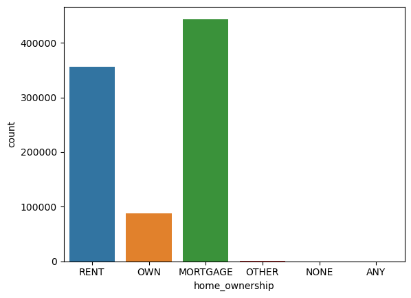

```
MORTGAGE    0.499851
RENT        0.401313
OWN         0.098571
OTHER       0.000205
NONE        0.000056
ANY         0.000003
Name: home_ownership, dtype: float64
```

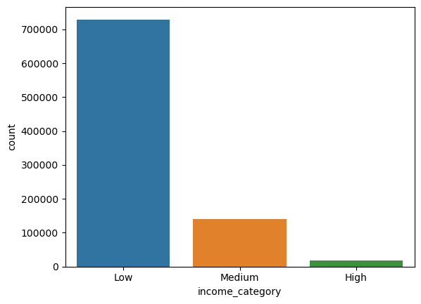

```
Low       0.822215
Medium    0.158869
High      0.018916
Name: income_category, dtype: float64
```

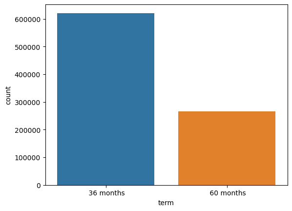

```
 36 months    0.699955
 60 months    0.300045
Name: term, dtype: float64
```

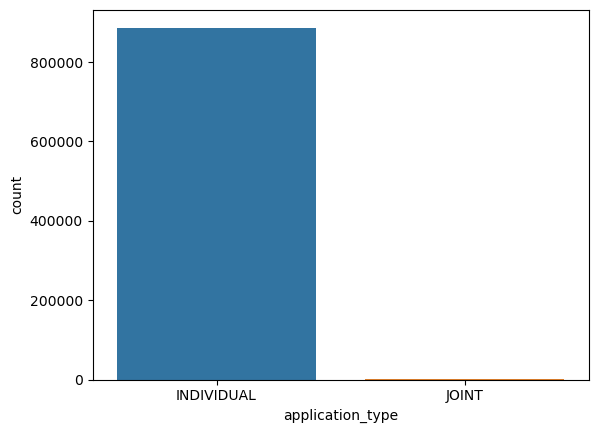

```
INDIVIDUAL    0.999424
JOINT         0.000576
Name: application_type, dtype: float64
```

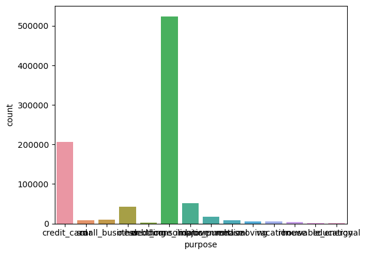

```
debt_consolidation    0.590745
credit_card           0.232349
home_improvement      0.058407
other                 0.048338
major_purchase        0.019470
small_business        0.011694
car                   0.009988
medical               0.009624
moving                0.006101
vacation              0.005337
house                 0.004177
wedding               0.002645
renewable_energy      0.000648
educational           0.000477
Name: purpose, dtype: float64
```

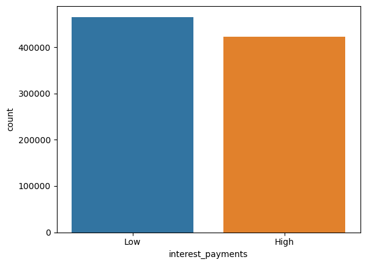

```
Low     0.524371
High    0.475629
Name: interest_payments, dtype: float64
```

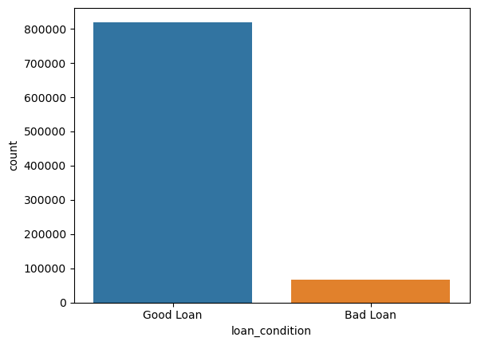

```
Good Loan    0.924013
Bad Loan     0.075987
Name: loan_condition, dtype: float64
```

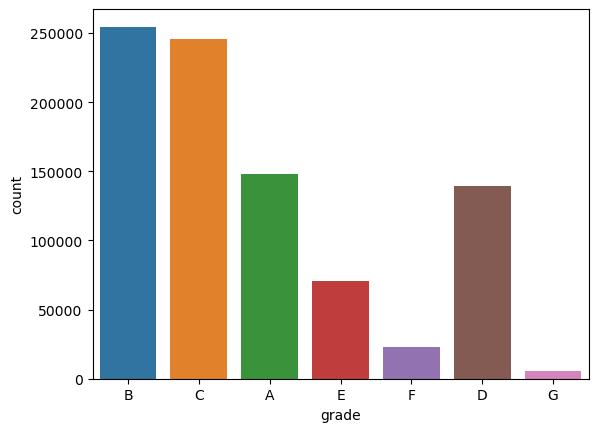

```
B    0.286839
C    0.277063
A    0.167011
D    0.157252
E    0.079678
F    0.025971
G    0.006186
Name: grade, dtype: float64
```

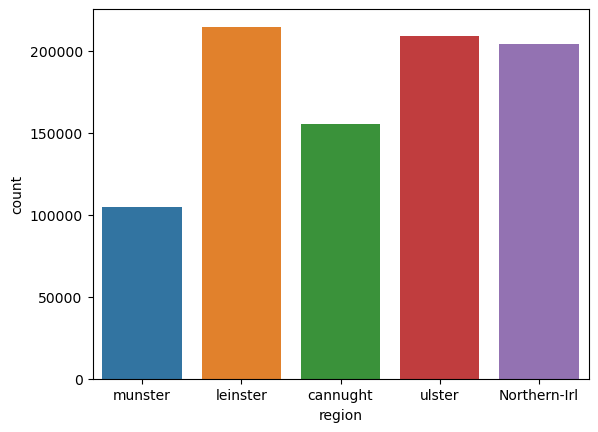

```
leinster        0.241888
ulster          0.235222
Northern-Irl    0.230340
cannught        0.174704
munster         0.117846
Name: region, dtype: float64
```

```python
for col in cat_cols:
    sns.countplot(data=df, x=col)
    plt.show()

    print(df[col].value_counts(normalize=True))
    print('\n')
```

## EDA Multivariate

Boxplot loan_condition_cat and numerical column comparison

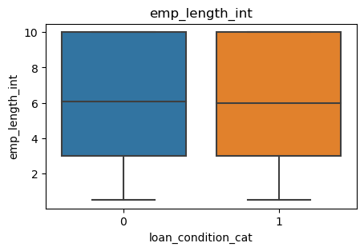

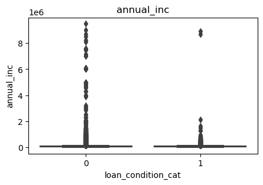

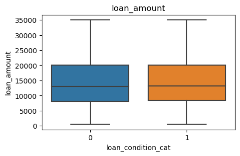

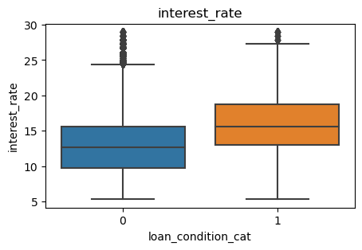

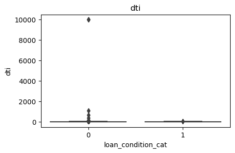

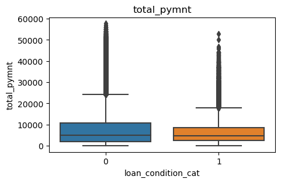

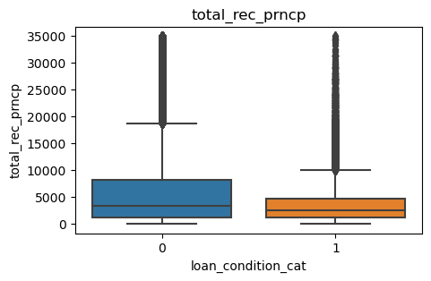

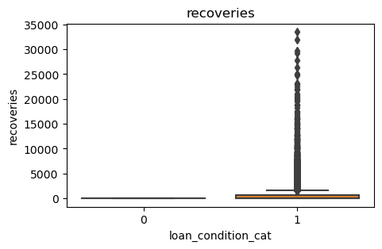

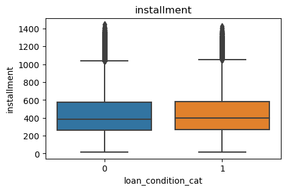

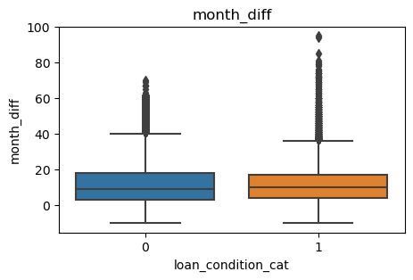

```python
for col in num_cols:
    plt.figure(figsize=(5,3))
    sns.boxplot(x='loan_condition_cat', y=col, data=df)
    plt.title(col)
    plt.show()
```

Counplot load_condition_cat and categorical variabel comparison

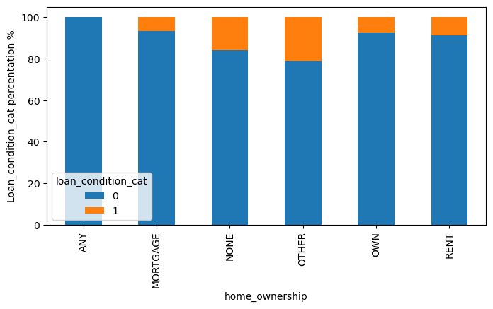

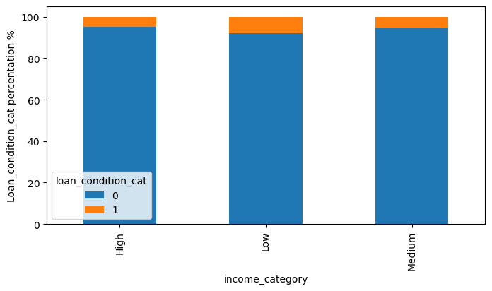

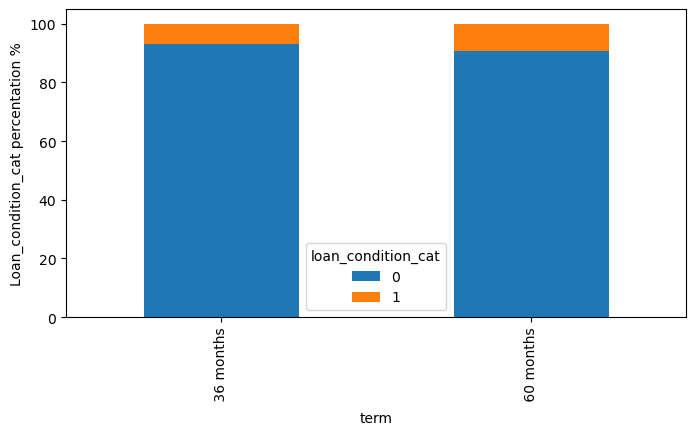

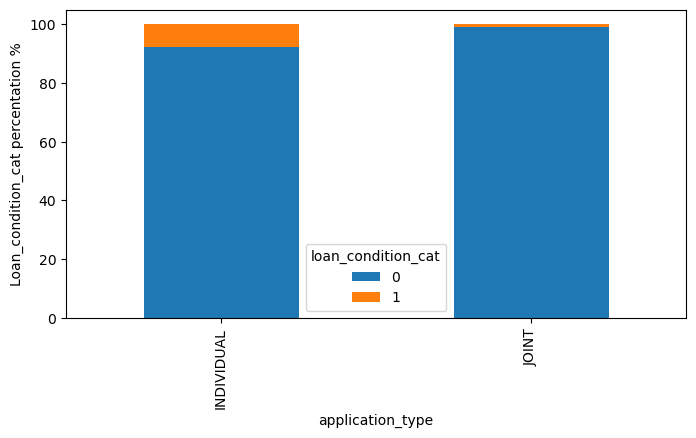

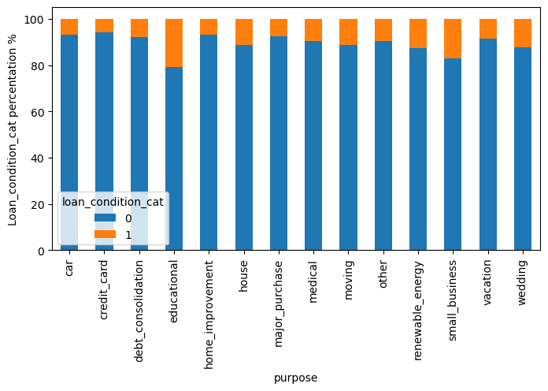

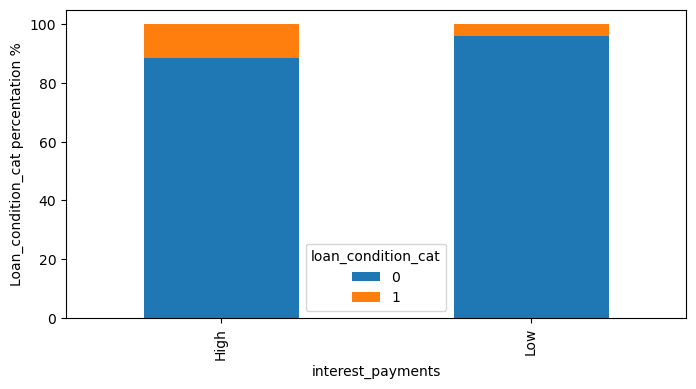

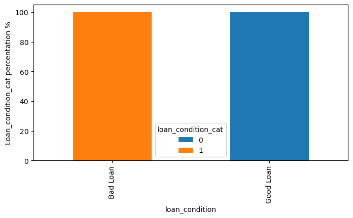

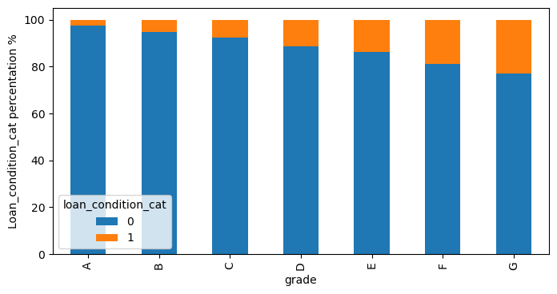

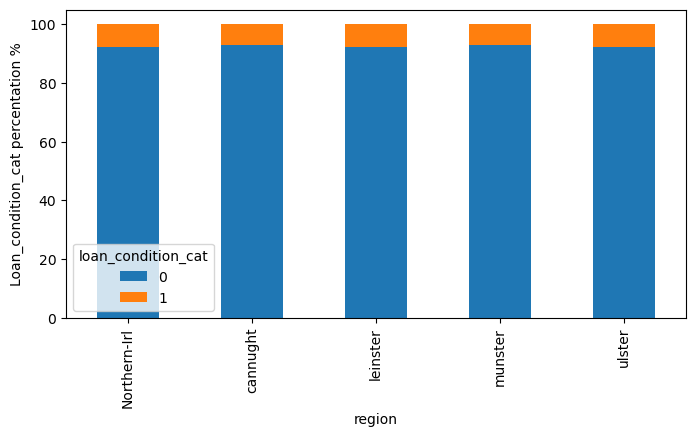

```python
for i in cat_cols:
    if i!='loan_condition_cat':
        (pd.crosstab(df[i],df['loan_condition_cat'],normalize='index')*100).plot(kind='bar',figsize=(8,4),stacked=True)
        plt.ylabel('Loan_condition_cat percentation %')
```

- I think the region have less correlation with load_condition_cat, so the column will be dropped.
- The target data is unbalance, I will use stratified sampling.

# Chi-squared and ANOVA test

First, I will try the chi-squared and ANOVA test between numerical columns and loan_condition_cat

```python
label_col = 'loan_condition_cat'

chi2_p_values = {}
for col in num_cols:
    crosstab = pd.crosstab(df[col], df[label_col])
    chi2, p, dof, expected = stats.chi2_contingency(crosstab)
    chi2_p_values[col] = p

for col, p_value in chi2_p_values.items():
    print(col, ": ", p_value)
```

```
emp_length_int :  6.347840291708608e-103
annual_inc :  9.655785817063468e-54
loan_amount :  0.0
interest_rate :  0.0
dti :  7.676563905147876e-16
total_pymnt :  0.0
total_rec_prncp :  0.0
recoveries :  0.0
installment :  0.0
month_diff :  0.0
```

Next, I do the ANOVA test.

```python
label_col = 'loan_condition_cat'

anova_p_values = {}
for col in num_cols:
    label_groups = []
    for label in df[label_col].unique():
        label_groups.append(df[df[label_col] == label][col])
    f_statistic, p_value = stats.f_oneway(*label_groups)
    anova_p_values[col] = p_value

for col, p_value in anova_p_values.items():
    print(col, ": ", p_value)
```

```
emp_length_int :  3.0993739060163267e-50
annual_inc :  4.392807818648234e-227
loan_amount :  0.0009393188860516072
interest_rate :  0.0
dti :  6.360203246409488e-21
total_pymnt :  0.0
total_rec_prncp :  0.0
recoveries :  0.0
installment :  2.1376247664646357e-40
month_diff :  0.3980879926581872
```

```python
target = 'loan_condition_cat'

# Loop through categorical columns and calculate chi-square test statistics and p-value
for col in cat_cols_new:
    contingency_table = pd.crosstab(df[col], df[target])
    chi2_stat, p_value, dof, expected = stats.chi2_contingency(contingency_table)
    print(f'{col}:\nchi-square statistic = {chi2_stat}\np-value = {p_value}\n')
```

```
home_ownership_cat:
chi-square statistic = 1336.624213287016
p-value = 7.422446573182584e-287

income_cat:
chi-square statistic = 1297.2767235163578
p-value = 1.9949808796129312e-282

term_cat:
chi-square statistic = 1390.6136957383824
p-value = 2.3019601782817004e-304

application_type_cat:
chi-square statistic = 30.97870889500134
p-value = 2.6087453841048543e-08

purpose_cat:
chi-square statistic = 3232.218290539413
p-value = 0.0

interest_payment_cat:
chi-square statistic = 17520.768449348012
p-value = 0.0

loan_condition_cat:
chi-square statistic = 887364.7576235114
p-value = 0.0

grade_cat:
chi-square statistic = 20328.382522497843
p-value = 0.0
```

```python
features=cat_cols_new+num_cols
features
```

```
['home_ownership_cat',
 'income_cat',
 'term_cat',
 'application_type_cat',
 'purpose_cat',
 'interest_payment_cat',
 'loan_condition_cat',
 'grade_cat',
 'emp_length_int',
 'annual_inc',
 'loan_amount',
 'interest_rate',
 'dti',
 'total_pymnt',
 'total_rec_prncp',
 'recoveries',
 'installment',
 'month_diff']
```

```python
df =df[features]
```

# Preprocessing

```python
#Split features and target
y= df.loan_condition_cat
X= df.drop(columns = ['loan_condition_cat'])
```

```python
X_train,X_test,y_train,y_test=train_test_split(X,y,test_size=0.2,random_state=1,stratify=y)
```

```python
# Create StandardScaler object
scaler = StandardScaler()

#Transform X_train
X_train_scaled = scaler.fit_transform(X_train)

#Transform X_test
X_test_scaled = scaler.transform(X_test)
```

# Traning Model

```python
# cross-validation for Logistic Regression
lr = LogisticRegression(max_iter=200)
param_grid_lr = {'C': [0.001, 0.01, 0.1, 1, 10, 100]}
grid_lr = GridSearchCV(lr, param_grid_lr, cv=5)
grid_lr.fit(X_train_scaled, y_train)
print("Best parameters for Logistic Regression:", grid_lr.best_params_)
lr_best = grid_lr.best_estimator_

# cross-validation for Decision Tree
dt = DecisionTreeClassifier()
param_grid_dt = {'max_depth': [1, 2, 3, 4, 5, 6, 7, 8, 9, 10]}
grid_dt = GridSearchCV(dt, param_grid_dt, cv=5)
grid_dt.fit(X_train_scaled, y_train)
print("Best parameters for Decision Tree:", grid_dt.best_params_)
dt_best = grid_dt.best_estimator_
```

```
Best parameters for Logistic Regression: {'C': 100}
Best parameters for Decision Tree: {'max_depth': 10}
```

```python
#XGBClassifier taking too long for large dataset, so I will split the data again and
# Subset data train and data test use only 0.5% from data train scaled
X_train_subset, _, y_train_subset, _ = train_test_split(X_train_scaled, y_train, test_size=0.99, random_state=42,stratify=y_train)

# cross-validation for XGBoost
xgb = XGBClassifier()
param_grid_xgb = {'max_depth': [1, 2, 3, 4, 5, 6, 7, 8, 9, 10], 'learning_rate': [0.001, 0.01, 0.1, 1]}
grid_xgb = GridSearchCV(xgb, param_grid_xgb, cv=5)
grid_xgb.fit(X_train_subset,y_train_subset)
print("Best parameters for XGBoost:", grid_xgb.best_params_)
xgb_best = grid_xgb.best_estimator_
```

```
Best parameters for XGBoost: {'learning_rate': 0.001, 'max_depth': 1}
```

```python
from keras.models import Sequential
from keras.layers import Dense
from sklearn.metrics import classification_report

# create model
model = Sequential()
model.add(Dense(32, activation='relu', input_dim=X_train_scaled.shape[1]))
model.add(Dense(16, activation='relu'))
model.add(Dense(1, activation='sigmoid'))

# compile model
model.compile(optimizer='adam', loss='binary_crossentropy', metrics=['accuracy'])

# fit the model with cross-validation
history = model.fit(X_train_scaled, y_train, epochs=10, batch_size=32, validation_split=0.2)
```

# Classification Report

```python
# fit with train set
lr_best.fit(X_train_scaled, y_train)
dt_best.fit(X_train_scaled, y_train)
xgb_best.fit(X_train_scaled, y_train)

# print classification report untuk train set dan test set
print("Classification report for Logistic Regression - train set:")
print(classification_report(y_train, lr_best.predict(X_train_scaled)))
print("Classification report for Logistic Regression - test set:")
print(classification_report(y_test, lr_best.predict(X_test_scaled)))

print("Classification report for Decision Tree - train set:")
print(classification_report(y_train, dt_best.predict(X_train_scaled)))
print("Classification report for Decision Tree - test set:")
print(classification_report(y_test, dt_best.predict(X_test_scaled)))

print("Classification report for XGBoost - train set:")
print(classification_report(y_train, xgb_best.predict(X_train_scaled)))
print("Classification report for XGBoost - test set:")
print(classification_report(y_test, xgb_best.predict(X_test_scaled)))

print("Classification report for NN - train set:")
print(classification_report(y_train, model.predict(X_train_scaled).round()))
print("Classification report for NN - test set:")
print(classification_report(y_test, model.predict(X_test_scaled).round()))
```

```
Classification report for Logistic Regression - train set:
              precision    recall  f1-score   support

           0       0.95      1.00      0.97    655960
           1       1.00      0.37      0.53     53943

    accuracy                           0.95    709903
   macro avg       0.97      0.68      0.75    709903
weighted avg       0.95      0.95      0.94    709903

Classification report for Logistic Regression - test set:
              precision    recall  f1-score   support

           0       0.95      1.00      0.97    163990
           1       1.00      0.37      0.54     13486

    accuracy                           0.95    177476
   macro avg       0.97      0.68      0.76    177476
weighted avg       0.95      0.95      0.94    177476

Classification report for Decision Tree - train set:
              precision    recall  f1-score   support

           0       0.95      1.00      0.98    655960
           1       0.99      0.42      0.59     53943

    accuracy                           0.96    709903
   macro avg       0.97      0.71      0.78    709903
weighted avg       0.96      0.96      0.95    709903

Classification report for Decision Tree - test set:
              precision    recall  f1-score   support

           0       0.95      1.00      0.98    163990
           1       0.99      0.41      0.58     13486

    accuracy                           0.95    177476
   macro avg       0.97      0.71      0.78    177476
weighted avg       0.96      0.95      0.95    177476

```

[output cut: 24 more lines]

```
           1       0.97      0.43      0.60     53943

    accuracy                           0.96    709903
   macro avg       0.97      0.72      0.79    709903
weighted avg       0.96      0.96      0.95    709903

Classification report for NN - test set:
              precision    recall  f1-score   support

           0       0.96      1.00      0.98    163990
           1       0.97      0.43      0.60     13486

    accuracy                           0.96    177476
   macro avg       0.96      0.71      0.79    177476
weighted avg       0.96      0.96      0.95    177476
```

# Conclusion

Based on the classification report, we can say the Neural Network (NN) model appears to be the best performer for both the train and test sets.